# Clase 8. ANOVA y test post hoc de Tukey.

#### **1. Cargar paquetes.**

En esta clase utilizaremos `ggplot2` (incluido en `tidyverse`), `readxl` para importar los datos, y `datasets`, que incluye la base de datos de ejemplo `iris`.

```r
library(tidyverse)
library(readxl)
library(datasets)
```

#### **2. ANOVA (Análisis de Varianza).**

El ANOVA es una prueba estadística que permite comparar las medias de **tres o más grupos** al mismo tiempo, determinando si al menos uno de ellos difiere significativamente de los demás. A diferencia del test t, que solo compara dos grupos, el ANOVA es útil cuando tenemos múltiples categorías.

Al igual que el test t, parte de una **hipótesis nula (H₀)** que asume que todos los grupos provienen de poblaciones con la misma media. Si el valor p obtenido es menor a 0.05, rechazamos la hipótesis nula y concluimos que existen diferencias significativas entre al menos dos grupos.

Sin embargo, el ANOVA no nos dice **cuáles** grupos difieren entre sí. Para eso necesitamos un **test post hoc**, como el **test de Tukey (TukeyHSD)**, que compara todos los pares de grupos posibles e indica cuáles tienen diferencias estadísticamente significativas.

En R, el flujo de trabajo es el siguiente:

```r
# 1. Correr el ANOVA y guardar el resultado en un objeto
resultado_anova <- aov(variable_cuantitativa ~ variable_cualitativa, data = nombre_datos)

# 2. Ver el resumen del ANOVA
summary(resultado_anova)

# 3. Correr el test post hoc de Tukey
TukeyHSD(resultado_anova)
```

#### **3. Ejercicio 1: Largo de pétalo en tres especies de *Iris*.**

Utilizaremos la base de datos `iris`, incluida en R, que contiene medidas de pétalos y sépalos para tres especies de plantas del género *Iris*. Compararemos el largo de pétalo entre las tres especies.

##### **3.1. Explorar los datos.**

```r
# La base de datos iris viene incluida en R
iris
```

```
##     Sepal.Length Sepal.Width Petal.Length Petal.Width    Species
## 1            5.1         3.5          1.4         0.2     setosa
## 2            4.9         3.0          1.4         0.2     setosa
## 3            4.7         3.2          1.3         0.2     setosa
## 4            4.6         3.1          1.5         0.2     setosa
## 5            5.0         3.6          1.4         0.2     setosa
## 6            5.4         3.9          1.7         0.4     setosa
## 7            4.6         3.4          1.4         0.3     setosa
## 8            5.0         3.4          1.5         0.2     setosa
## 9            4.4         2.9          1.4         0.2     setosa
## 10           4.9         3.1          1.5         0.1     setosa
## 11           5.4         3.7          1.5         0.2     setosa
## 12           4.8         3.4          1.6         0.2     setosa
## 13           4.8         3.0          1.4         0.1     setosa
## 14           4.3         3.0          1.1         0.1     setosa
```

[output cut: 136 more lines]

Exploramos los datos con un boxplot.

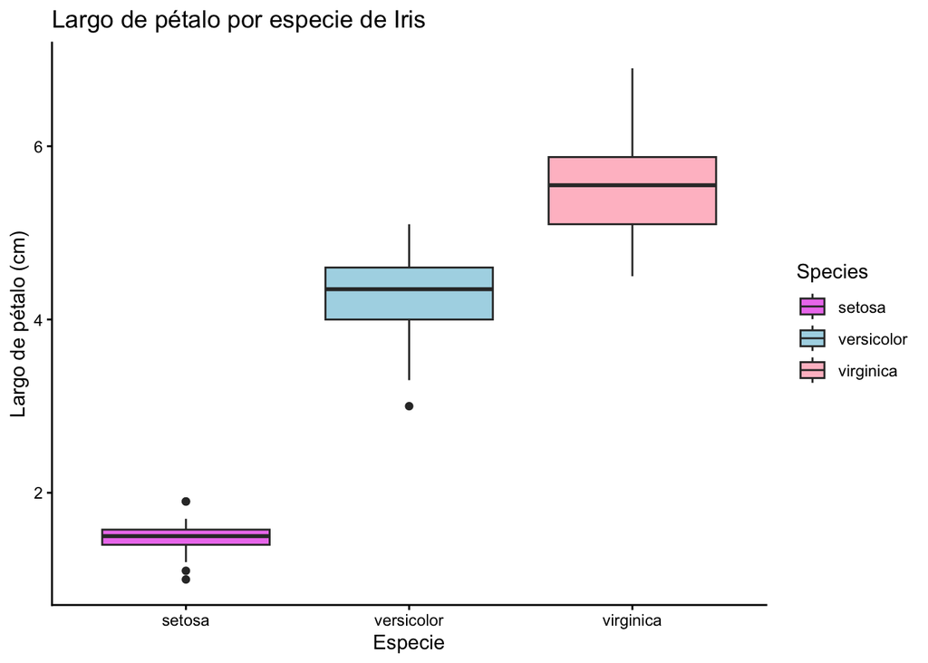

```r
ggplot(data = iris, aes(x = Species, y = Petal.Length, fill = Species)) +
  geom_boxplot() +
  scale_fill_manual(values = c("violet", "lightblue", "pink")) +
  labs(x = "Especie", y = "Largo de pétalo (cm)", title = "Largo de pétalo por especie de Iris") +
  theme_classic()
```

##### **3.2. Correr el ANOVA.**

```r
anova_iris <- aov(Petal.Length ~ Species, data = iris)
summary(anova_iris)
```

```
##              Df Sum Sq Mean Sq F value Pr(>F)
## Species       2  437.1  218.55    1180 <2e-16 ***
## Residuals   147   27.2    0.19
## ---
## Signif. codes:  0 '***' 0.001 '**' 0.01 '*' 0.05 '.' 0.1 ' ' 1
```

##### **3.3. Test post hoc de Tukey.**

```r
TukeyHSD(anova_iris)
```

```
##   Tukey multiple comparisons of means
##     95% family-wise confidence level
##
## Fit: aov(formula = Petal.Length ~ Species, data = iris)
##
## $Species
##                       diff     lwr     upr p adj
## versicolor-setosa    2.798 2.59422 3.00178     0
## virginica-setosa     4.090 3.88622 4.29378     0
## virginica-versicolor 1.292 1.08822 1.49578     0
```

##### **3.4. Interpretación.**

¿Podemos rechazar la hipótesis nula? ¿Qué nos indica el test de Tukey sobre cuáles especies tienen diferencias significativas entre sí?

#### **4. Ejercicio 2: Isótopos de nitrógeno en cultivos a través del tiempo.**

Compararemos los valores de δ15N en cultivos arqueológicos de cuatro períodos distintos: Formativo, Período Intermedio Tardío, Período Tardío y Período Colonial.

##### **4.1. Importar y explorar los datos.**

```r
cultivos <- read_excel("~/Desktop/work/0_Cuantitativa_2026/ANT305Q-2026/Clases/Clase8/Nitrogeno_cultivos.xls")
cultivos
```

```
## # A tibble: 196 × 2
##     d15N Periodo
##    <dbl> <chr>
##  1  13.3 Formativo
##  2   3.4 Formativo
##  3  11.3 Formativo
##  4   6.9 Formativo
##  5   8.3 Formativo
##  6   9.9 Formativo
##  7  14.7 Formativo
##  8  12.2 Formativo
##  9   6.6 Formativo
## 10   9.1 Formativo
## # ℹ 186 more rows
```

Antes de graficar, ordenamos los períodos cronológicamente usando la función `factor()`. Sin esto, R los ordenaría alfabéticamente.

```r
cultivos$Periodo <- factor(cultivos$Periodo, levels = c("Formativo", "Periodo Intermedio Tardio", "Periodo Tardio", "Periodo Colonial"))
```

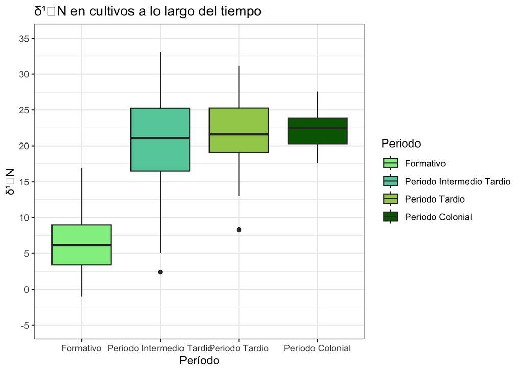

```r
ggplot(data = cultivos, aes(x = Periodo, y = d15N, fill = Periodo)) +
  geom_boxplot() +
  scale_fill_manual(values = c("lightgreen", "aquamarine3", "darkolivegreen3", "darkgreen")) +
  scale_y_continuous(limits = c(-5, 35), breaks = seq(-5, 35, 5)) +
  labs(x = "Período", y = "δ¹⁵N", title = "δ¹⁵N en cultivos a lo largo del tiempo") +
  theme_bw()
```

##### **4.2. Correr el ANOVA.**

```r
anova_cultivos <- aov(d15N ~ Periodo, data = cultivos)
summary(anova_cultivos)
```

```
##              Df Sum Sq Mean Sq F value Pr(>F)
## Periodo       3   9565    3188   115.1 <2e-16 ***
## Residuals   192   5318      28
## ---
## Signif. codes:  0 '***' 0.001 '**' 0.01 '*' 0.05 '.' 0.1 ' ' 1
```

##### **4.3. Test post hoc de Tukey.**

```r
TukeyHSD(anova_cultivos)
```

```
##   Tukey multiple comparisons of means
##     95% family-wise confidence level
##
## Fit: aov(formula = d15N ~ Periodo, data = cultivos)
##
## $Periodo
##                                                 diff       lwr       upr
## Periodo Intermedio Tardio-Formativo        13.911603 11.692099 16.131106
## Periodo Tardio-Formativo                   15.555899 12.613369 18.498428
## Periodo Colonial-Formativo                 15.827363 11.708206 19.946519
## Periodo Tardio-Periodo Intermedio Tardio    1.644296 -1.231390  4.519982
## Periodo Colonial-Periodo Intermedio Tardio  1.915760 -2.155916  5.987436
## Periodo Colonial-Periodo Tardio             0.271464 -4.235289  4.778217
##                                                p adj
## Periodo Intermedio Tardio-Formativo        0.0000000
## Periodo Tardio-Formativo                   0.0000000
## Periodo Colonial-Formativo                 0.0000000
## Periodo Tardio-Periodo Intermedio Tardio   0.4504196
## Periodo Colonial-Periodo Intermedio Tardio 0.6153012
## Periodo Colonial-Periodo Tardio            0.9986409
```

##### **4.4. Interpretación.**

¿Podemos rechazar la hipótesis nula? ¿Entre qué períodos existen diferencias significativas según el test de Tukey? ¿Qué podría indicar esto sobre los cambios en las prácticas agrícolas a lo largo del tiempo?

#### **5. Trabajo en Clases 8.**

Para esta actividad utilizaremos la base de datos `palmerpenguins`, que contiene medidas morfológicas de tres especies de pingüinos de las Islas Palmer en la Antártida.

```r
# Instalar el paquete (solo la primera vez)
install.packages("palmerpenguins")
```

```r
library(palmerpenguins)
penguins
```

```
## # A tibble: 344 × 8
##    species island    bill_length_mm bill_depth_mm flipper_length_mm body_mass_g
##    <fct>   <fct>              <dbl>         <dbl>             <int>       <int>
##  1 Adelie  Torgersen           39.1          18.7               181        3750
##  2 Adelie  Torgersen           39.5          17.4               186        3800
##  3 Adelie  Torgersen           40.3          18                 195        3250
##  4 Adelie  Torgersen           NA            NA                  NA          NA
##  5 Adelie  Torgersen           36.7          19.3               193        3450
##  6 Adelie  Torgersen           39.3          20.6               190        3650
##  7 Adelie  Torgersen           38.9          17.8               181        3625
##  8 Adelie  Torgersen           39.2          19.6               195        4675
##  9 Adelie  Torgersen           34.1          18.1               193        3475
## 10 Adelie  Torgersen           42            20.2               190        4250
## # ℹ 334 more rows
## # ℹ 2 more variables: sex <fct>, year <int>
```

1. Compare el largo de aleta (`flipper_length_mm`) entre las tres especies de pingüinos usando ANOVA. Recuerde explorar los datos primero con un boxplot, luego corra el ANOVA y el test de Tukey. ¿Podemos rechazar la hipótesis nula? ¿Entre qué especies existen diferencias significativas?
2. Compare el peso corporal (`body_mass_g`) entre las tres especies usando ANOVA. Recuerde explorar los datos primero con un boxplot, luego corra el ANOVA y el test de Tukey. ¿Podemos rechazar la hipótesis nula? ¿Entre qué especies existen diferencias significativas?

← Clase Anterior Índice Siguiente Clase →